# CITY_US_new

# 1 Предварительный анализ данных

```r
if (interactive() && !str_ends(getwd(), "R/stat_anal/CITY_US")) {
    setwd("R/stat_anal/CITY_US")
}

data <- read_excel("CITY_shortname.xls")
data[data == "NA"] <- NA
data[, -(1:2)] <- data.frame(lapply(data[, -(1:2)], as.numeric))
fullnames <- names(read_excel("CITY.xls"))
```

## 1.1 Разобраться в том, что означают признаки.

```r
print(fullnames)
```

```
##  [1] "CITY City"
##  [2] "STATE State"
##  [3] "AREA Land area, 1990 (sq.miles)"
##  [4] "R_AREA Land area, 1990 (sq.miles), ranks"
##  [5] "POP92 Population,1992"
##  [6] "R_POP92 Population,1992, ranks"
##  [7] "POP80 Population,1980"
##  [8] "R_POP80 Population,1980, ranks"
##  [9] "POP_CH Population growth rate,1980-1992"
## [10] "R_POP_CH Population growth rate,1980-1992, ranks"
## [11] "POPDEN Population per square mile, 1992"
## [12] "R_POPDEN Population per square mile, 1992, ranks"
## [13] "OLD % older 65 years"
## [14] "R_OLD % older 65 years, ranks"
## [15] "BLACK Black population,1990"
```

[output cut: 59 more lines]

## 1.2 Отобрать признаки

```r
names_interesting <- c("AREA", "POP80", "POP92", "POPDEN", "CRIME", "BORN_F", "POVERT", "INCOME", "UNEMP", "TEMPER")

data <- data %>% select(all_of(c("CITY", "STATE", names_interesting)))

print(head(data))
```

```
## # A tibble: 6 × 12
##   CITY  STATE  AREA  POP80  POP92 POPDEN CRIME BORN_F POVERT INCOME UNEMP TEMPER
##   <chr> <chr> <dbl>  <dbl>  <dbl>  <dbl> <dbl>  <dbl>  <dbl>  <dbl> <dbl>  <dbl>
## 1 NEW_… NY     309. 7.07e6 7.31e6  23671  9236   28.4   19.3  29823   8.6   76.8
## 2 LOS_… CA     469. 2.97e6 3.49e6   7436  9730   38.4   18.9  30925   9     74.3
## 3 CHIC… IL     227. 3.01e6 2.77e6  12185    NA   16.9   21.6  26301   8.4   75.1
## 4 HOUS… TX     540. 1.60e6 1.69e6   3131 10824   17.8   20.7  26261   6.1   83.5
## 5 PHIL… PA     135. 1.69e6 1.55e6  11492  6835    6.6   20.3  24603   8     76.7
## 6 SAN_… CA     324  8.76e5 1.15e6   3546  8537   20.9   13.4     10   6.2   71
```

## 1.3 Определить вид признаков

Город и штат качественные, остальные количественные, ранги были порядковыми.

```r
find_mode_freq <- function(x) {
    x <- x[!is.na(x)]
    return(max(tabulate(match(x, x))))
}

print(data %>% summarise(across(
    all_of(names_interesting),
    find_mode_freq
)))
```

```
## # A tibble: 1 × 10
##    AREA POP80 POP92 POPDEN CRIME BORN_F POVERT INCOME UNEMP TEMPER
##   <int> <int> <int>  <int> <int>  <int>  <int>  <int> <int>  <int>
## 1     1     1     1      2     1      4      2      1     5      3
```

```r
print(sort(data$UNEMP))
```

```
##  [1]  2.3  3.2  3.8  3.9  4.1  4.4  4.6  4.7  4.7  4.8  4.8  5.0  5.0  5.0  5.0
## [16]  5.1  5.1  5.1  5.3  5.4  5.4  5.4  5.4  5.4  5.6  5.7  5.9  5.9  5.9  6.0
## [31]  6.0  6.1  6.1  6.1  6.1  6.2  6.2  6.4  6.4  6.5  6.7  6.7  6.7  6.8  6.9
## [46]  6.9  7.0  7.1  7.2  7.2  7.3  7.3  7.3  7.5  7.6  7.7  7.7  7.7  8.0  8.1
## [61]  8.4  8.4  8.5  8.6  9.0  9.0  9.4  9.5  9.6 10.0 10.4 10.6 10.7 11.0 11.9
## [76] 12.6 13.1
```

Все количественные буду считать непрерывными. возможно UNEMP непрерывный с плохой точностью.

## 1.4 не актуально

## 1.5 Построить matrix plot

```r
# if (interactive()) pdf("ggpairs_unedited.pdf")
# ggpairs(
#     data[, -(1:2)],
#     lower = list(continuous = wrap("points", alpha = 0.5, size = 0.3)),
#     diag = list(continuous = "barDiag")
# )
# if (interactive()) dev.off()
```

## 1.7 outliers

Убираю outliers:

Помечаю некорректные данные в INCOME как NA. Удаляю город из Аляски за плотность населения. Флорида выделсется на BORN_F-INCOME Гаваи выделяются низким уровнем безработицы. странно?

```r
data$INCOME[data$INCOME < 100] <- NA
data <- data %>% filter(STATE != "AK")
```

## 1.6 Несимметричные распределения

Функция, которая логарифмирует, если это сделает выборку симметричнее

```r
log_asymmetric <- function(x) {
    if (skewness(x, na.rm = TRUE) < abs(skewness(log(x), na.rm = TRUE))) {
        print("default")
        return(x)
    } else {
        print("logged")
        return(log(x))
    }
}
```

Автоматически логарифмирую то что имеет асимметрию и длинный хвост справа

```r
data_logged <- data %>%
    mutate(across(all_of(names_interesting), log_asymmetric))
```

```
## [1] "logged"
## [1] "logged"
## [1] "logged"
## [1] "logged"
## [1] "logged"
## [1] "logged"
## [1] "default"
## [1] "default"
## [1] "logged"
## [1] "default"
```

```r
# if (interactive()) pdf("ggpairs_logged.pdf")
# ggpairs(
#     data_logged[, -(1:2)],
#     lower = list(continuous = wrap("points", alpha = 0.5, size = 0.3)),
#     diag = list(continuous = "barDiag")
# )
# if (interactive()) dev.off()
```

## 1.8 однородность

выглядит однородно.

## .9 не актуально

## 1.10 всякие характеристики

```r
print_characteristics <- function(x) {
    list(
        mean = mean(x, na.rm = TRUE),
        var = var(x, na.rm = TRUE),
        skewness = skewness(x, na.rm = TRUE),
        kurtosis = kurtosis(x, na.rm = TRUE) - 3
    )
}

sapply(data_logged %>% select(all_of
(names_interesting)), print_characteristics)
```

```
##          AREA       POP80     POP92     POPDEN     CRIME      BORN_F
## mean     4.754638   12.9069   13.01226  8.257586   9.206558   1.959747
## var      0.6658984  0.5142076 0.4464288 0.5099096  0.06798296 0.8435754
## skewness 0.1317646  1.453879  1.743773  0.1015321  0.1476689  0.3081197
## kurtosis -0.3907363 3.033026  3.885752  -0.1531417 0.08872069 -0.7431516
##          POVERT     INCOME     UNEMP      TEMPER
## mean     18.11842   25282.48   1.873674   77.60132
## var      34.68872   14321837   0.09967048 37.59853
## skewness 0.2243883  -0.2196584 -0.2186434 -0.1426746
## kurtosis -0.3539569 -0.6467894 0.6594639  0.7472063
```

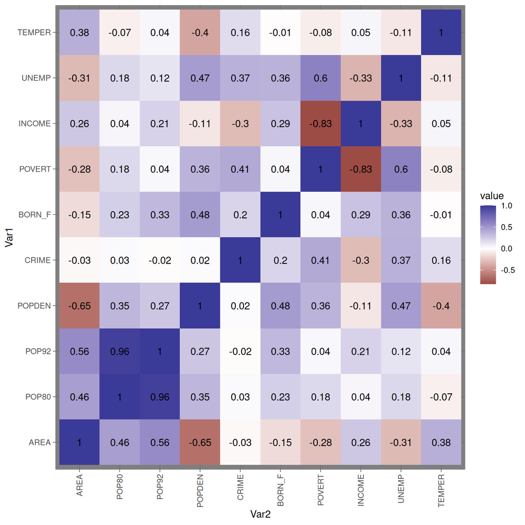

```r
df <- data_logged %>%
    select(-CITY, -STATE) %>%
    drop_na()

ggplot(melt(cor(df))) +
    geom_raster(aes(x = Var2, y = Var1, fill = value)) +
    geom_text(aes(x = Var2, y = Var1, label = round(value, 2))) +
    scale_fill_gradient2() +
    theme_dark() +
    theme(axis.text.x = element_text(angle = 90, vjust = 0.5, hjust = 1))
```

# 2 Задаете зависимые и ‘независимые’ переменные (регрессоры), не забываете обратить внимание на выбор способа обработки пропущенных наблюдений, функция lm.

```r
df <- data_logged %>%
    select(-CITY, -STATE, -POP92, -POVERT, -POPDEN) %>%
    drop_na()

model <- lm.beta(lm(CRIME ~ ., data = df, na.action = na.exclude))
# model.beta <- lm.beta(model)
# summary(model)
summary(model)
```

```
##
## Call:
## lm(formula = CRIME ~ ., data = df, na.action = na.exclude)
##
## Residuals:
##      Min       1Q   Median       3Q      Max
## -0.48908 -0.12199 -0.03883  0.14268  0.57840
##
## Coefficients:
##               Estimate Standardized Std. Error t value Pr(>|t|)
## (Intercept)  9.276e+00           NA  8.350e-01  11.110 5.44e-16 ***
## AREA         5.952e-02    2.028e-01  5.084e-02   1.171   0.2464
## POP80       -5.338e-02   -1.510e-01  5.440e-02  -0.981   0.3305
## BORN_F       7.568e-02    2.709e-01  4.079e-02   1.855   0.0686 .
## INCOME      -2.168e-05   -3.417e-01  8.949e-06  -2.422   0.0186 *
## UNEMP        2.088e-01    2.596e-01  1.163e-01   1.795   0.0778 .
## TEMPER       5.021e-03    1.220e-01  5.418e-03   0.927   0.3579
## ---
## Signif. codes:  0 '***' 0.001 '**' 0.01 '*' 0.05 '.' 0.1 ' ' 1
##
## Residual standard error: 0.2183 on 58 degrees of freedom
## Multiple R-squared:  0.2613, Adjusted R-squared:  0.1848
## F-statistic: 3.419 on 6 and 58 DF,  p-value: 0.005876
```

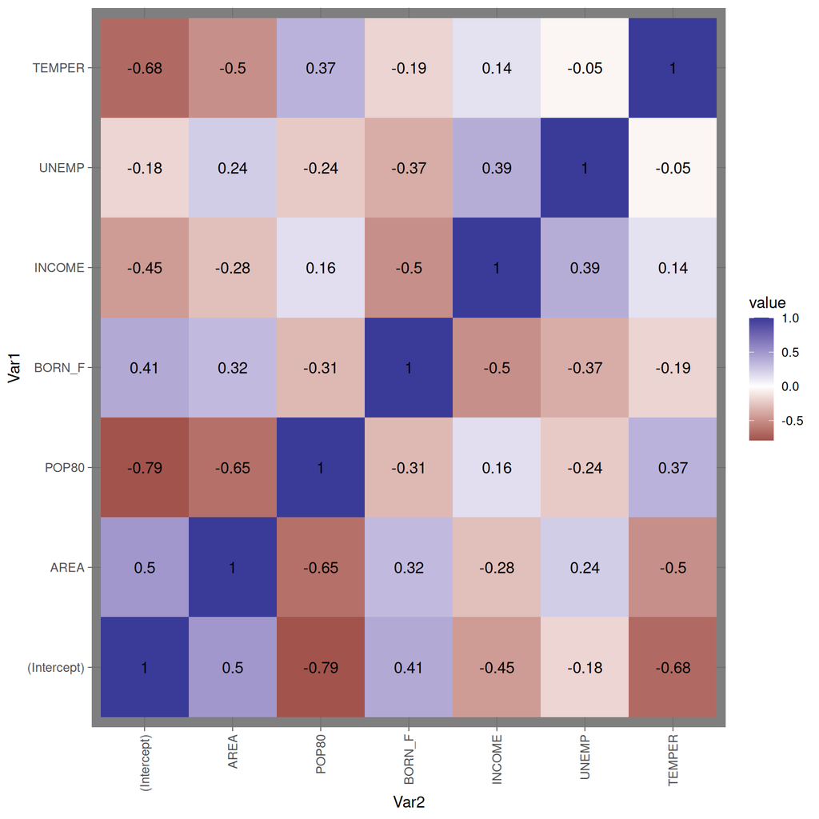

```r
ggplot(melt(cov2cor(vcov(model)))) +
    geom_raster(aes(x = Var2, y = Var1, fill = value)) +
    geom_text(aes(x = Var2, y = Var1, label = round(value, 2))) +
    scale_fill_gradient2() +
    theme_dark() +
    theme(axis.text.x = element_text(angle = 90, vjust = 0.5, hjust = 1))
```

```r
# cov2cor(vcov(model))
```

# 3 Интерпретируете результаты регрессии, включая результат lm.beta (в частности, о разнице между b и beta, о значимости и пр.).

# 4 Далее есть три проблемы, из-за которых результаты регрессии могут быть неправильными

## линейная модель регрессии не соответствует даннымв данных

```
жаль
```

## могут быть сильно зависимые «независимые» переменные

```
есть население в 80 и 92
```

## также могут быть outliers.

```
outliers уже убраны, если какие-то и остались, это не так критично
```

# 5 Как строятся доверительные интервалы и двумерные доверительные области.

На примере пары признаков строите двумерный доверительный интервал для пары значащих коэффициентов регрессии, интерпретируете: (1) оба признака влияют на результат согласно оценкам коэффициентов регрессии перед ними: или (2) признаки вместе сильно влияют, но не различить, какой из них больше; или (3) непонятно, или оба признака слабо влияют, или оба влияют сильно.

```r
# df <- data_logged %>% select(-CITY, -STATE)

# model2 <- lm.beta(lm(CRIME ~ POVERT + UNEMP, data = df, na.action = na.exclude))
# # summary(model)
# summary(model2)


# cov_matrix <- vcov(model2)
# # cor_matrix <- cov2cor(vcov(model2))

# ggplot(melt(cov2cor(cov_matrix))) +
#     geom_raster(aes(x = Var2, y = Var1, fill = value)) +
#     geom_text(aes(x = Var2, y = Var1, label = round(value, 2))) +
#     scale_fill_gradient2() +
#     theme_dark() +
#     theme(axis.text.x = element_text(angle = 90, vjust = 0.5, hjust = 1))

# cov2cor(vcov(model))
```

```r
plot_ellipse <- function(model_, id) {
    # model_ <- model

    mean <- model_$standardized.coefficients[id]

    sd <- cov2cor(vcov(model_))[id, id]

    # id <- c(3, 6)

    net <- expand.grid(list(
        x = seq(mean[1] - 3, mean[1] + 3, by = .1),
        y = seq(mean[2] - 3, mean[2] + 3, by = .1)
    )) %>%
        mutate(
            z = dmvnorm(cbind(x, y), mean, sd)
        )

    ggplot() +
        # geom_point(data = ring, aes(x = x, y = y)) +
        geom_point(data = data.frame(x = 0, y = 0), aes(x = x, y = y), size = 5) +
        geom_contour(data = net, aes(x = x, y = y, z = z))

    # plot()
}
```

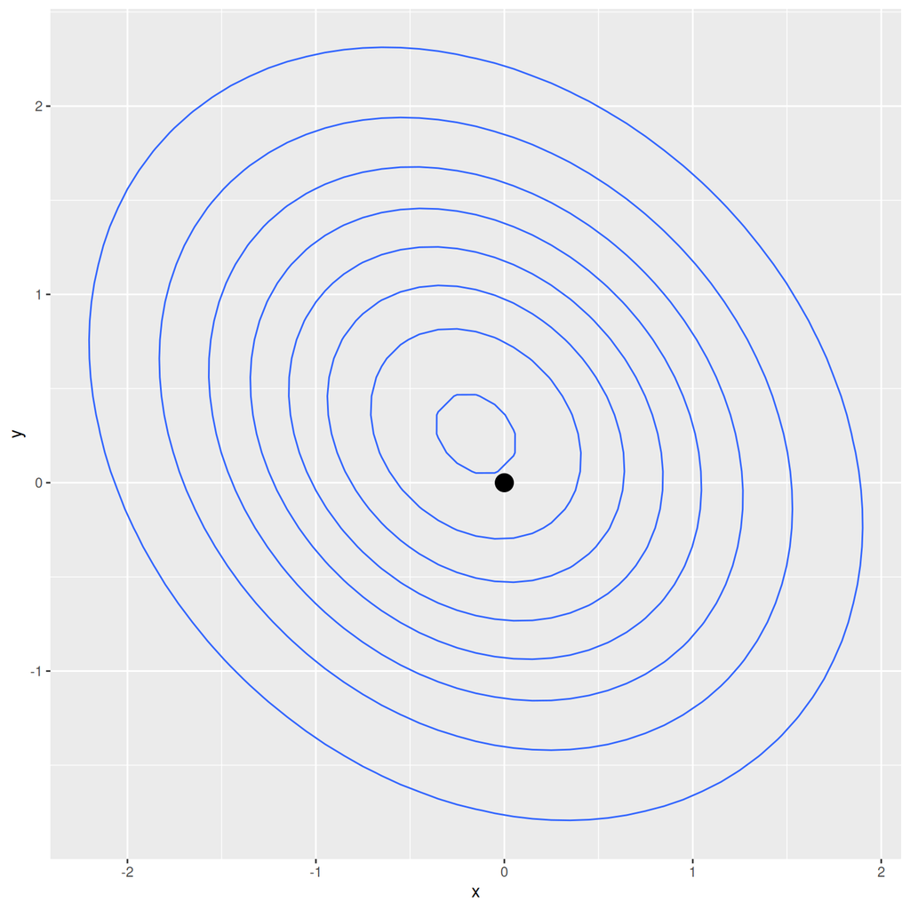

```r
plot_ellipse(model, c(3, 6))
```

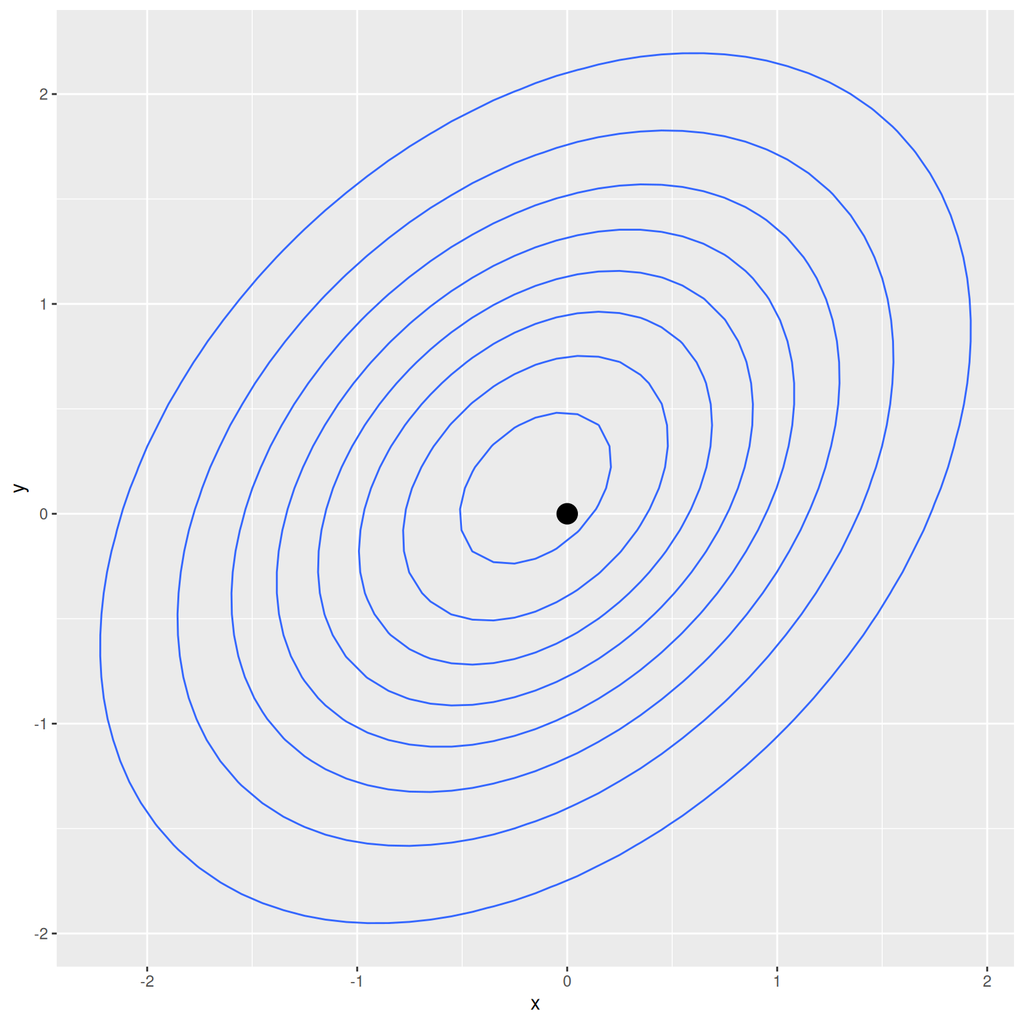

```r
plot_ellipse(model, c(3, 7))
```

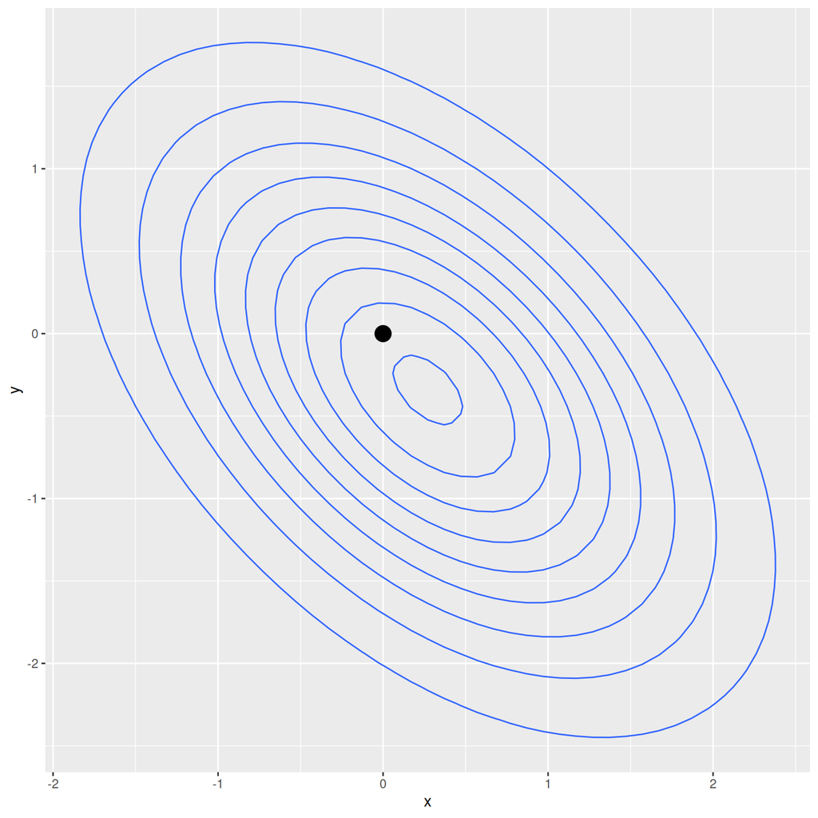

```r
# plot_ellipse(model, c(3, 8))
# plot_ellipse(model, c(3, 9))
# plot_ellipse(model, c(3, 10))
plot_ellipse(model, c(4, 5))
```

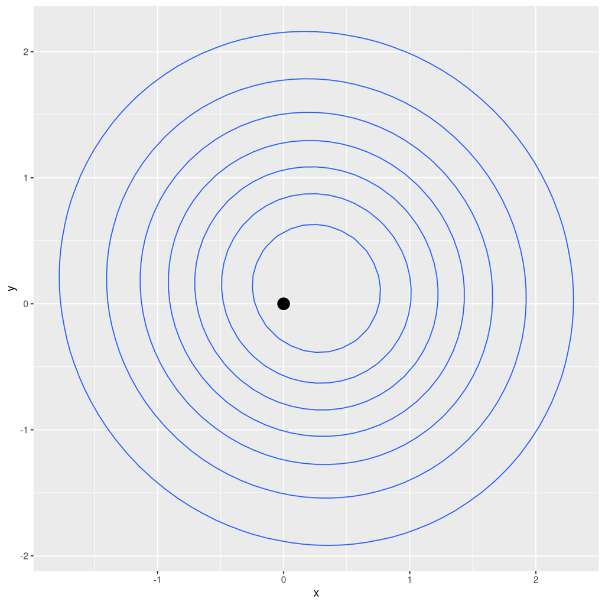

```r
plot_ellipse(model, c(6, 7))
```

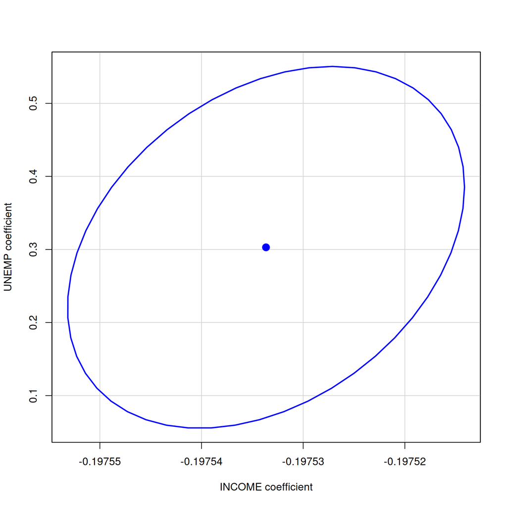

```r
confidenceEllipse(lm.beta(lm(CRIME ~ INCOME + UNEMP, data = df)))
```